# IODS course project

### T for test and A for Anova (Group 1 and 2)

```r
# Perform a three-sample t-test
RATSL9S1 <- data.frame(
  Group = c(1, 1, 1, 1, 1, 1, 1, 1, 2, 2, 2),
  mean = c(261.0909, 237.6364, 260.1818, 266.5455, 269.4545, 274.7273, 274.6364, 265.4545, 440.8182, 452.7273, 454.81822)
)
t.test(mean ~ Group, data = RATSL9S1)
```

```
##
##  Welch Two Sample t-test
##
## data:  mean by Group
## t = -30.709, df = 5.9527, p-value = 8.748e-08
## alternative hypothesis: true difference in means between group 1 and group 2 is not equal to 0
## 95 percent confidence interval:
##  -200.5670 -170.9104
## sample estimates:
## mean in group 1 mean in group 2
##        263.7159        449.4546
```

```r
# Add the baseline from the original data as a new variable to the summary data
RATSL9S2 <- RATSL9S %>%
  mutate(baseline = RATS$WD1)

# Fit the linear model with the mean as the response
fit <- lm(mean ~ baseline + Group, data = RATSL9S2)

# Compute the analysis of variance table for the fitted model with anova()
anova_table <- anova(fit)
anova_table
```

```
## Analysis of Variance Table
##
## Response: mean
##           Df Sum Sq Mean Sq   F value    Pr(>F)
## baseline   1 252125  252125 2237.0655 5.217e-15 ***
## Group      2    726     363    3.2219   0.07586 .
## Residuals 12   1352     113
## ---
## Signif. codes:  0 '***' 0.001 '**' 0.01 '*' 0.05 '.' 0.1 ' ' 1
```

The Two Sample t-test indicates a significant difference between the means of group 1 and group 2. However, the ANOVA suggests that the overall difference among the three groups (including group 3) is not statistically significant.

### T for test and A for Anova (Group 2 and 3)

```r
RATSL9S1 <- data.frame(
  Group = c(2, 2, 2, 3, 3, 3, 3),
  mean = c(440.8182, 452.7273, 454.81822, 492.9091, 536.2727, 540.1818, 533.8182)
)
t.test(mean ~ Group, data = RATSL9S1)
```

```
##
##  Welch Two Sample t-test
##
## data:  mean by Group
## t = -6.4314, df = 3.8677, p-value = 0.003371
## alternative hypothesis: true difference in means between group 2 and group 3 is not equal to 0
## 95 percent confidence interval:
##  -109.74654  -42.93521
## sample estimates:
## mean in group 2 mean in group 3
##        449.4546        525.7954
```

```r
# Add the baseline from the original data as a new variable to the summary data
RATSL9S2 <- RATSL9S %>%
  mutate(baseline = RATS$WD1)

# Fit the linear model with the mean as the response
fit <- lm(mean ~ baseline + Group, data = RATSL9S2)

# Compute the analysis of variance table for the fitted model with anova()
anova_table <- anova(fit)
anova_table
```

```
## Analysis of Variance Table
##
## Response: mean
##           Df Sum Sq Mean Sq   F value    Pr(>F)
## baseline   1 252125  252125 2237.0655 5.217e-15 ***
## Group      2    726     363    3.2219   0.07586 .
## Residuals 12   1352     113
## ---
## Signif. codes:  0 '***' 0.001 '**' 0.01 '*' 0.05 '.' 0.1 ' ' 1
```

The Two Sample t-test suggests a significant difference between the means of group 2 and group 3, but the ANOVA results indicate that there’s no significant overall difference among the three groups. This discrepancy might be due to the specific pairwise comparison being more sensitive to the differences between certain groups.

## Meet and Repeat: PART II

### BPRS data preparation

```r
library(tidyr)
library(dplyr)

# read in the RATS data
BPRS <- read.table("https://raw.githubusercontent.com/KimmoVehkalahti/MABS/master/Examples/data/BPRS.txt", sep =" ", header = T)

# Factor variables treatment and subject
BPRS$treatment <- factor(BPRS$treatment)
BPRS$subject <- factor(BPRS$subject)

# Convert to long form (BPRS)
BPRSL <-  pivot_longer(BPRS, cols = -c(treatment, subject),
                       names_to = "weeks", values_to = "bprs") %>%
  arrange(weeks)

# Extract the week number
BPRSL <-  BPRSL %>%
            mutate(week = as.integer(substr(weeks, 5,5)))
```

### Draw a plot

```r
# Check the dimensions of the data
dim(BPRSL)
```

```
## [1] 360   5
```

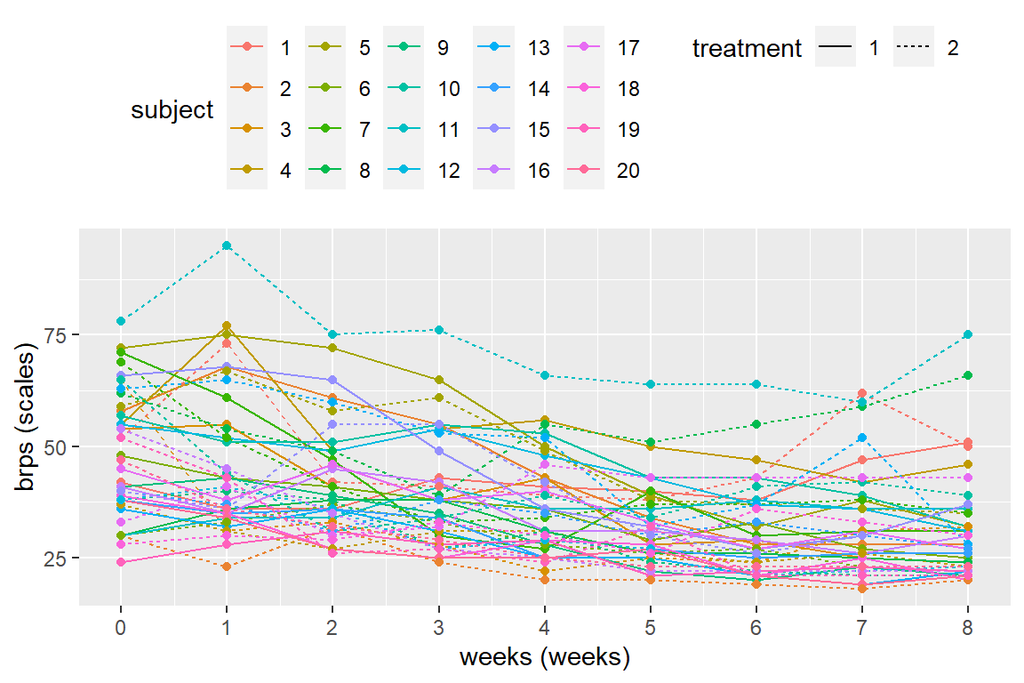

```r
# Plot the RATSL data
library(ggplot2)
ggplot(BPRSL, aes(x = week, y = bprs, color = subject, linetype = treatment)) +
  geom_line()+
  geom_point()+
  scale_x_continuous(name = "weeks (weeks)", breaks = seq(0, 8, 1))+
  scale_y_continuous(name = "brps (scales)")+
  theme(legend.position = "top")
```

The data set BPRSL has 360 observations and 5 variables. The value of brief psychiatric rating scale decreased after 8 weeks’ treatment. The men who have higher BPRS values at the beginning tend to have higher values throughout the study.